# Modeling Polygenic Risk

Dennis J. Hazelett & Simon G. Coetzee

# Generating fake patient data (Hardy-Weinberg)

Generation of fake patient data (i.e. simulation of) is pretty easy. Human variation is codified as “single nucleotide polymorphisms” (alternatively “simple nuc poly”) or [SNPs](https://en.wikipedia.org/wiki/Single-nucleotide_polymorphism). First let’s create some functions to simulate genotypes based on SNP frequency. This is based on the [Hardy-Weinberg equilibrium](https://en.wikipedia.org/wiki/Hardy%E2%80%93Weinberg_principle) We can add risk effects later.

```r
library(ggplot2)
library(reshape2)

# function to calculate genotype frequency given the population frequency of one of two alleles.

genotype_prob <- function(maf) {
  #hardy-weinberg model
  p <- maf
  q <- 1-p
  x <- c(q^2, 2*p*q, p^2)
  x
}
```

Let’s create a tool to generate a fixed number of patient genotypes based on a set of SNPs with known population frequency. Since we’re exploring parameter space, I want my function to be able to take some simulated allele frequencies (‘my_p’) and odds ratios (‘effect_size’).

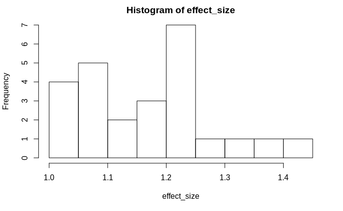

```r
pt_genotypes <- function(num_pts, snp_ids, my_p, effect_size) {
  genotype_mat <- matrix(NA, length(snp_ids), num_pts)
  for (i in 1:length(snp_ids)) {
    genotype_mat[i,] <- sample(c(0,1,2), size = num_pts, prob = genotype_prob(my_p[i]), replace = T)
  }
  genotype_mat <- data.frame(genotype_mat, maf=my_p, row.names = snp_ids, OR = effect_size)
  genotype_mat
}

# parameter block
##################
num_pts <- 100000
num_snps <- 25
maf_sd <- 0.3 # standard dev for normal dist of minor allele freq
set.seed(1492)
effect_size <- 1 + abs(rnorm(num_snps, 0, 0.2))
baserate <- 0.001
ages <- rnorm(num_pts, 65, 3)
ages <- rep(65, num_pts)
##################

# Simulate some SNP odds ratios:

hist(effect_size)
```

```r
pts <- pt_genotypes(num_pts, paste(rep("rs", num_snps), sample(5e8, size=num_snps, replace = F), sep=""),
                    signif( abs(rnorm(num_snps, 0, maf_sd)), digits=2),
                    effect_size = effect_size)

# Here's some useful info:
# the average of our SNPs odds ratios
mean(pts$OR)
```

```
[1] 1.168758
```

```r
# the average allele frequency
mean(pts$maf)
```

```
[1] 0.205
```

```r
# let's get a look at how the genotypes look for a handful of patients
pts[1:5, 1:8]
```

|  | X1 | X2 | X3 | X4 | X5 | X6 | X7 | X8 |
| --- | --- | --- | --- | --- | --- | --- | --- | --- |
| rs335063536 | 0 | 0 | 0 | 0 | 0 | 0 | 0 | 0 |
| rs78744790 | 0 | 0 | 0 | 0 | 0 | 0 | 0 | 1 |
| rs24866920 | 0 | 0 | 0 | 1 | 0 | 1 | 0 | 1 |
| rs453440269 | 1 | 1 | 0 | 1 | 1 | 1 | 1 | 0 |
| rs337366173 | 0 | 0 | 0 | 1 | 0 | 0 | 0 | 1 |

```r
NA
```

# Calculation of patient genotype based risk probability

These SNPs confer risk for some disease, like being a baseball fan, at known effect sizes. In human genetics the effect sizes are expressed as odds ratios (OR). In plain language, this means the increased chance that you would get your disease (or become a baseball fan) that is associated with one out of two possible risk alleles (since humans and baseball fans are diploid). Let’s suppose the population (which lacks risk alleles) has a baseline rate of 0.005, i.e. that 0.5% of people would be baseball fans without a risk allele. If the odds ratio at a particular locus were 1.2, the risk of being a baseball fan is $1.2 \times 0.005 = 0.006$. The probability for a homozygote heterozygous for another SNP with OR 1.4 would be $1.2^2 \times 1.4 \times 0.005 = 0.01008$ and so on. Also the cumulative OR for this patient would be $1.2^2 \times 1.4 = 2.016$, so you could say this person is twice as likely as a typical person lacking the risk alleles to be a baseball fan.

Given that we have a bunch of genotypes and a simple formula for calculating risk, lets do that now for each patient.

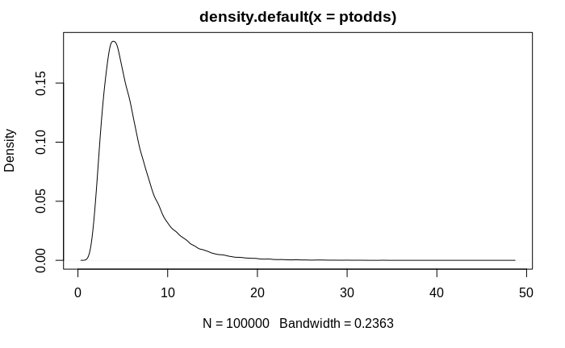

```r
# After some experimenting, the vectorized form of this calculation is significantly faster, but requires that we carry it out in log space

ptodds <- exp(colSums(log(pts$OR ^ pts[,1:num_pts])))

# look at the distribution of unadjusted patient odds:
plot(density(ptodds))
```

Now we have a little book-keeping to take care of. Firstly, we have to make some adjustments for age-related risk, and secondly, the odds are relative to the baseline rate, let’s call it the “baserate” or the population average.

## Adjustment for risk based on age

Assume the GWAS odds ratios are obtained under conditions where two patient populations, cases and controls, have been age matched, say at age 60-65. In practice this is how these studies are done. What that means is that the lifetime risk at ~65 yrs is equal to the GWAS odds ratio. We would like to have a general description of risk and genotype that includes age, so we can handle age similar to the way you might amortize your taxes for a home lone, by dividing the risk into equal chunks over the life of the GWAS. There are probably better (non-linear) descriptions of age related risk, but for now we’ll use this as an approximation. Here’s what it looks like in R code.

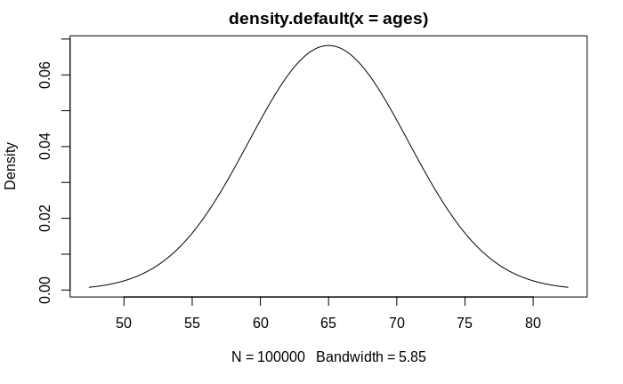

```r
ptodds.age <- ptodds/65 * ages
plot(density(ages))
```

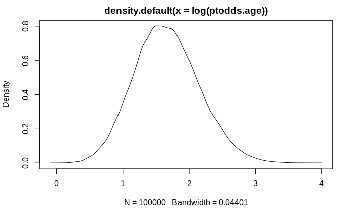

```r
plot(density(log(ptodds.age)))
```

## Adjustment for population average risk

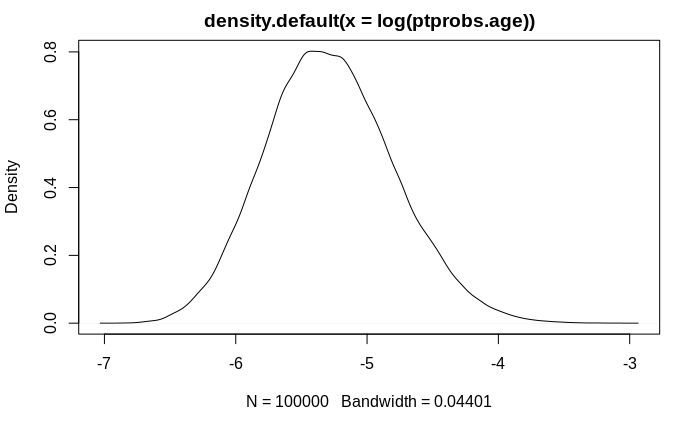

```r
popscale.factor <- 0.005/median(ptodds)
# put it together with the age adjustment
ptprobs.age <- ptodds/65 * ages * popscale.factor
plot(density(log(ptprobs.age)))
```

## Simulating phenotypes

We can represent our phenotype as a boolean value and sample from boolean space using each patient’s individual risk ratio: ### Setup

```r
# generate cases 'n ctrls from polygenic risk data
#########################
sick <- numeric(num_pts)
set.seed(99)
for (i in 1:num_pts) {
  sick[i] <- sample(c(0,1), size=1, prob = c(1-ptprobs.age[i], ptprobs.age[i]))
}
cases <- which(sick==TRUE)
length(cases)
```

```
[1] 565
```

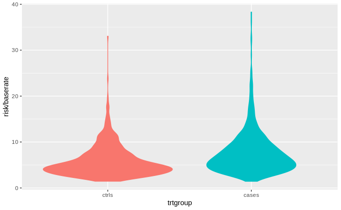

```r
# get an equal number of controls (non-sick people)
ctrls <- sample(which(sick==FALSE), size = length(cases), replace = FALSE)
ptrisk <- melt(data.frame(ctrls=ptprobs.age[ctrls], cases=ptprobs.age[cases]))
names(ptrisk) <- c("trtgroup", "risk")
#########################

# violin plot compare distributin relative risk of cases controls
ggplot(data=ptrisk, aes(x=trtgroup, y=risk/baserate, colour=trtgroup, fill=trtgroup)) + geom_violin() + theme(legend.position = "none")
```

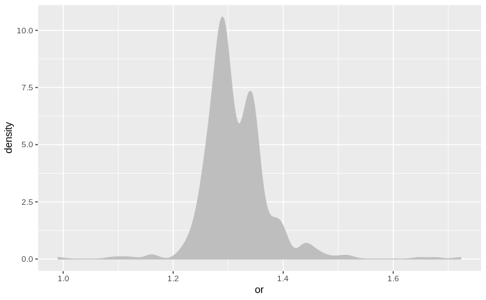

```r
# distribution of case odds vs control odds
ggplot(data=data.frame(or=ptprobs.age[cases][order(ptprobs.age[cases])]/ptprobs.age[ctrls][order(ptprobs.age[ctrls])]), aes(x=or)) + geom_density(fill="grey", colour="grey")
```

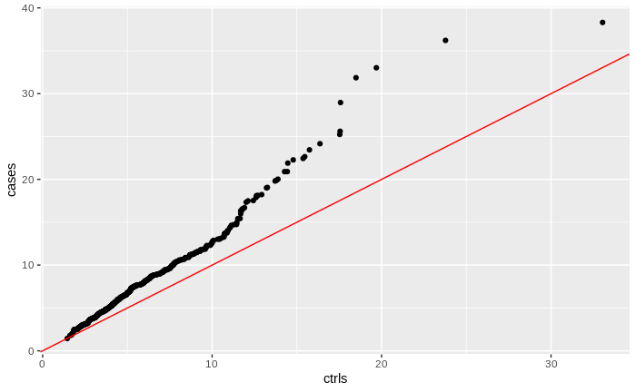

```r
# cases vs control ORs relative to line of unity
ggplot(data=data.frame(cases=ptprobs.age[cases][order(ptprobs.age[cases])]/baserate, ctrls=ptprobs.age[ctrls][order(ptprobs.age[ctrls])]/baserate), aes(x=ctrls, y=cases)) +
  geom_point() + #xlim(0, 100) + ylim(0, 100) +
  geom_abline(intercept = 0, slope = 1, colour="red")
```

```r
caseOR <- ptprobs.age[cases][order(ptprobs.age[cases])]/baserate
ctrlOR <- ptprobs.age[ctrls][order(ptprobs.age[ctrls])]/baserate
# % of cases OR > 5
length(which(caseOR>5))
```

```
[1] 389
```

```r
length(which(caseOR>5))/length(caseOR)
```

```
[1] 0.6884956
```

```r
# slope
mean(caseOR/ctrlOR)
```

```
[1] 1.313238
```

### Explanation

What I’ve done is taken a matched group of patients and controls and ranked them by genetic risk. Clearly the distribution of risk is shifted for the cases relative to the controls, causing the points to be all to the left of the line of unity (they won’t always be so, but we got lucky this time). The slope of the points can be approximated by taking the mean of case/ctrl. This is analagous to a q-q plot. What would happen if we repeated this whole experiment with increased effect sizes or allele frequency? It takes a long time to run the simulation, so I’ll just put a table here where I’ve repeated with varying parameter inputs.[^1] Note that ‘mafsd’ and ‘orsd’ are the parameter inputs in the code above, to generate SNP properties.

| meanAF | mafsd | meanOR | orsd | slope | OR5 | ncases | pct |
| --- | --- | --- | --- | --- | --- | --- | --- |
| 0.0829 | 0.10 | 1.21 | 0.2 | 1.20 | 133 | 2255 | 5.9% |
| 0.0731 | 0.10 | 1.10 | 0.1 | 1.03 | 0 | 1438 | 0% |
| 0.1121 | 0.20 | 1.19 | 0.2 | 1.18 | 209 | 2428 | 8.6% |
| 0.3434 | 0.30 | 1.20 | 0.2 | 1.39 | 151 | 151 | 100% |
| 0.0512 | 0.05 | 1.26 | 0.3 | 1.22 | 135 | 2050 | 6.6% |
| 0.0371 | 0.05 | 1.35 | 0.4 | 1.23 | 101 | 1867 | 5.4% |
| 0.1023 | 0.10 | 1.38 | 0.4 | 1.95 | 451 | 579 | 78% |

Now that we have some background on population genotype simulation and parameters, let’s apply it to a real-world example.

# Application to Ovarian Cancer

I work on Ovarian Cancer so I’m curious to apply this model using some real SNPs that have been discovered in GWAS. There are actually 5 subtypes of Ovarian cancer, but I’ll focus on the most common one to keep things simple for now. Later, it should be possible to create a panel of SNPs to calculate risk probability for a bunch of diseases or subtypes simultaneously.

## Simulation from GWAS SNPs

We can leverage all the code from the previous sections to simulate a patient population using the GWAS SNPs, their allele frequencies in Europeans, and the Odds Ratios. We’re constructing a scenario for predicting a patient population that behaves, phenotypically speaking, according to the rules we laid out before.

### Setup

To get started, I went to the [gwas catalog](https://www.ebi.ac.uk/gwas/) and fetched 12 independent risk loci. We’ll go ahead and repeat all the calculations as before, generating the distribution graphs so we can compare them to the results in the previous sections. We also overwrite some of the previous parameters, like the baseline population rate of ovarian cancer (1.3%), and we set a seed for repeatability.

| SNP_ID | Odds_Ratio | Risk_Allele_Freq |
| --- | --- | --- |
| rs7651446 | 1.590000 | 0.05000 |
| rs3814113 | 1.265823 | 0.32000 |
| rs10088218 | 1.298701 | 0.13000 |
| rs9303542 | 1.140000 | 0.27000 |
| rs8170 | 1.190000 | 0.19000 |
| rs2072590 | 1.140000 | 0.68000 |
| rs34289250 | 7.950000 | 0.00890 |
| rs11782652 | 1.240000 | 0.07000 |
| rs1243180 | 1.100000 | 0.31000 |
| rs11907546 | 1.111111 | 0.35903 |
| rs2046210 | 1.280000 | 0.08000 |
| rs10069690 | 1.140000 | 0.26000 |

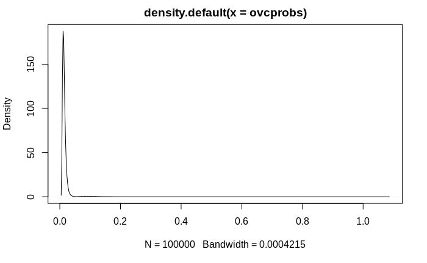

named integer(0) [1] 1044 No id variables; using all as measure variables

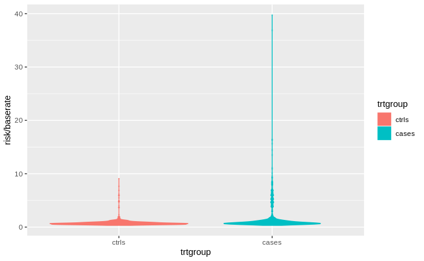

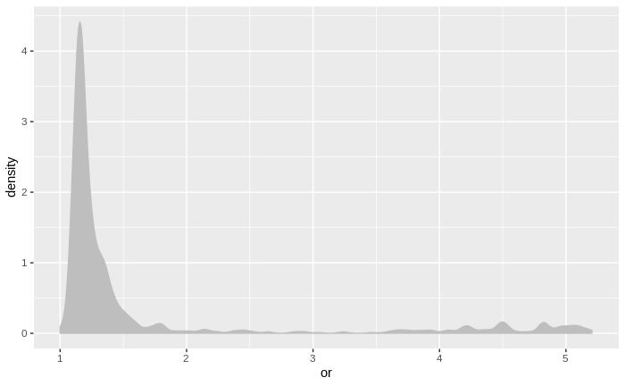

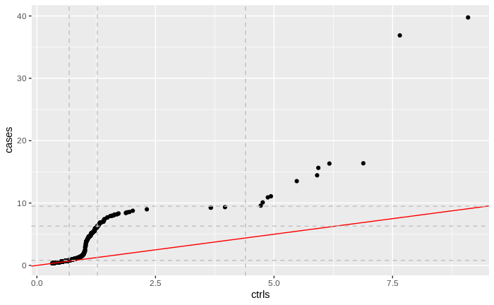

## Large effect mutations (BRCA1 & 2)

### Setup

We’ll have to reformulate our risk formula a little bit, but to save time I’ll borrow the previously generated ORs.

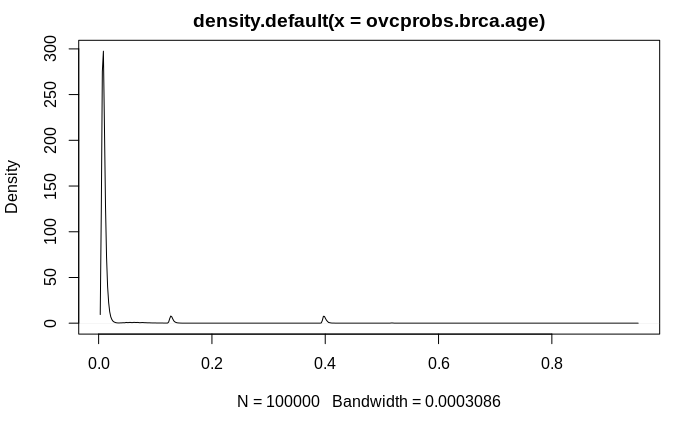

```r
################### BRCA Muts

brca1.prob <- 0.025
brca1.OR <- .39 # technically not an OR
brca2.prob <- 0.02
brca2.OR <- .12

ovcprobs.brca.age <- ovcprobs.age +
  brca1.OR*sample(c(0,1), size=num_pts, prob=c(1-brca1.prob, brca1.prob), replace=TRUE) +
  brca2.OR*sample(c(0,1), size=num_pts, prob=c(1-brca1.prob, brca1.prob), replace=TRUE)
ovcprobs.brca.age <- ovcprobs.brca.age[valid.patients]

plot(density(ovcprobs.brca.age))
```

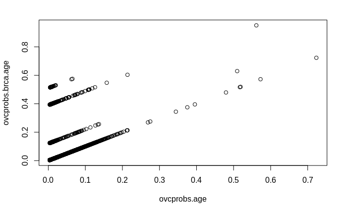

```r
plot(x=ovcprobs.age, y=ovcprobs.brca.age)
```

```r
#FUN=function(x) {baserate*prod(pts$OR^x)}
# generate cases 'n ctrls from polygenic risk data
#########################
ovcsick.brca <- numeric(length(valid.patients))
for (i in 1:length(ovcprobs.brca.age)) {
  ovcsick.brca[i] <- sample(c(0,1), size=1, prob = c(1-ovcprobs.brca.age[i], ovcprobs.brca.age[i]))
}
cases <- which(ovcsick.brca==TRUE)
length(cases)
```

```
[1] 2315
```

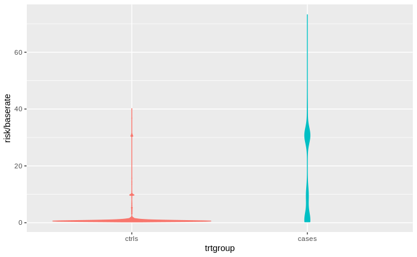

```r
ctrls <- sample(which(ovcsick.brca==FALSE), size = length(cases), replace = FALSE)
ptrisk <- melt(data.frame(ctrls=ovcprobs.brca.age[ctrls], cases=ovcprobs.brca.age[cases]))
names(ptrisk) <- c("trtgroup", "risk")
#########################

# violin plot compare distributin relative risk of cases controls
ggplot(data=ptrisk, aes(x=trtgroup, y=risk/baserate, colour=trtgroup, fill=trtgroup)) + geom_violin() + theme(legend.position = "none")
```

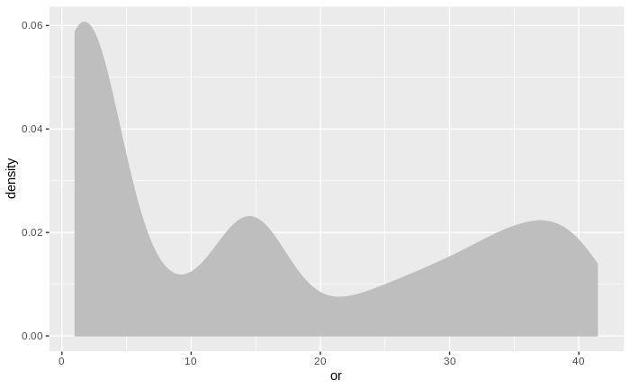

```r
ggplot(data=data.frame(or=ovcprobs.brca.age[cases][order(ovcprobs.brca.age[cases])]/ovcprobs.brca.age[ctrls][order(ovcprobs.brca.age[ctrls])]), aes(x=or)) + geom_density(fill="grey", colour="grey")
```

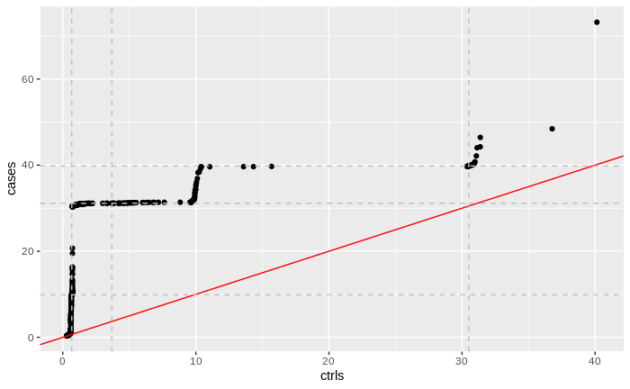

```r
ggplot(data=data.frame(cases=ovcprobs.brca.age[cases][order(ovcprobs.brca.age[cases])]/baserate, ctrls=ovcprobs.brca.age[ctrls][order(ovcprobs.brca.age[ctrls])]/baserate), aes(x=ctrls, y=cases)) +
  geom_point() +
  geom_abline(intercept = 0, slope = 1, colour="red") +
  geom_hline(yintercept=quantile(ovcprobs.brca.age[cases]/baserate, probs=c(.5,.95,.99)), colour="grey", lty=2) +
  geom_vline(xintercept=quantile(ovcprobs.brca.age[ctrls]/baserate, probs=c(.5,.95,.99)), colour="grey", lty=2)
```

### Explanation

```r
caseOR <- ovcprobs.brca.age[cases][order(ovcprobs.brca.age[cases])]/baserate
ctrlOR <- ovcprobs.brca.age[ctrls][order(ovcprobs.brca.age[ctrls])]/baserate
# % of cases OR > 5
length(which(caseOR>5))
```

```
[1] 1381
```

```r
length(which(caseOR>5))/length(caseOR)
```

```
[1] 0.5965443
```

```r
# slope
mean(caseOR/ctrlOR)
```

```
[1] 15.53026
```

## BRCA mutations as regular SNPs 3/14/2017

Above I’ve modeled BRCA mutations as risk factors. It is sensible to do this, because BRCA mutations are varied and rare, but in aggregate quite common (with a couple notable exceptions). In any case we’re just averaging them out as a kind of fudge. In the near future, I expect better information to become available on individual BRCA mutations, including allele frequency and odds-ratios. So I want build a dummy model around this situation, just to see what adding a few large-effect mutations and modeling them *as snps* will do.

### Creating patient data

I’m using the same ovarian SNPs as before, adding some fake BRCA1 mutations. Note that I am also creating a categorical variable to aid in plotting and analysis later. In addition, I’m adding other known risk genes based on data in Norquist et al (2016)[^3].

```r
################### BRCA Muts
brca1.prob <- 0.0031
brca2.prob <- 0.0041
brca1.OR <- 29
brca2.OR <- 12.7
prevalence <- 0.013

ovc_snps <- c("rs7651446", "rs3814113", "rs10088218", "rs9303542", "rs8170", "rs2072590", "rs34289250",
              "rs11782652", "rs1243180", "rs11907546", "rs2046210", "rs10069690",
              "brca1", "brca2", "brip1", "palb2", "rad51c", "rad51d", "bard1",
              "chek2", "atm", "nbn", "tp53", "rad50", "fam174a", "mre11a")
ovc_or   <- c(1.59, 1.2658228, 1.2987013, 1.14, 1.19, 1.14, 7.95, 1.24, 1.1, 1.1111112, 1.28, 1.14,
              brca1.OR, brca2.OR, 6.4, 4.4, 3.4, 10.9,
              4.2, 0.4, 2.4, 2.3, 2.9, 0.7, 1.9, 0.8)
ovc_maf  <- c(0.05, 0.32, 0.13, 0.27, 0.19, 0.68, 0.0089, 0.07, 0.31, .35903, 0.08, 0.26,
              brca1.prob, brca2.prob, 0.0017, 0.0011, 0.0011, 0.0004, 0.0005,
              0.0082, 0.0022, 0.0014, 0.0011, 0.0024, 0.0008, 0.0007)


ovcpts <- pt_genotypes(num_pts, ovc_snps, ovc_maf, effect_size = ovc_or)
ovcodds <- exp(colSums(log(ovcpts$OR ^ ovcpts[,1:num_pts])))
brca.carrier <- rep("NON-BRCA", num_pts)
brca.carrier[which(ovcpts[14,1:1e5]>0)] <- "BRCA2"
brca.carrier[which(ovcpts[13,1:1e5]>0)] <- "BRCA1" # assign brca1 last in case of overwriting double mutation status
```

### Setup

As before, I want to scale the probabilities so that the mean roughly matches the overall prevalence. The ``popscale.factor’’ variable is akin to saying “this is the amount of residual risk when you remove all the risky alleles from the population”. This number can never be zero (unless we discover a preventive measure that is 100% effective), but the more risk factors we know the lower its variance will be. For now we will treat it as a constant.

```r
ovcprobs.brca <- ovcodds
popscale.factor <- prevalence / mean(ovcprobs.brca)
valid.patients <- which(ovcprobs.brca*popscale.factor < 1)
nvalid <- length(valid.patients)
```

### Age model

I want to explore how risk changes over a persons lifetime, given different genotype backgrounds.

#### Exponential version

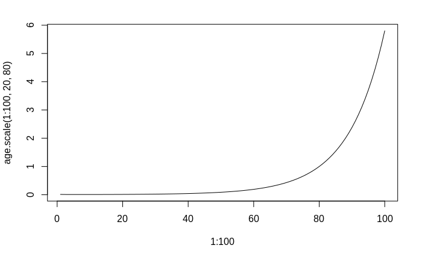

```r
# demonstrate age scalar:
# create a func
age.scale <- function(age, onset.age, risk.age) {
  # age is the patient age
  # onset.age is the age at which the process begins to accelerate
  # risk.age is the age at which lifetime risk accumulates to its maximum
  1/risk.age * age^((age-onset.age)/(risk.age-onset.age))
}

plot(x=1:100, y=age.scale(1:100, 20, 80), type='l')
```

#### Inverse logit version

With the exponential version I was getting a risk multiplier of 41% for age 70 vs 100% at age 80. This doesn’t make sense, so I created an inverse_logit function to make a nice S-curve between 0 and 1. I’ve abandoned the exponential version for now, but I’m keeping the code in this place to document my learning process, and just in case I want to use it again.

There is already an inverse logit function in the “boot” package, but it is not flexible enough for my needs, so here’s my version.

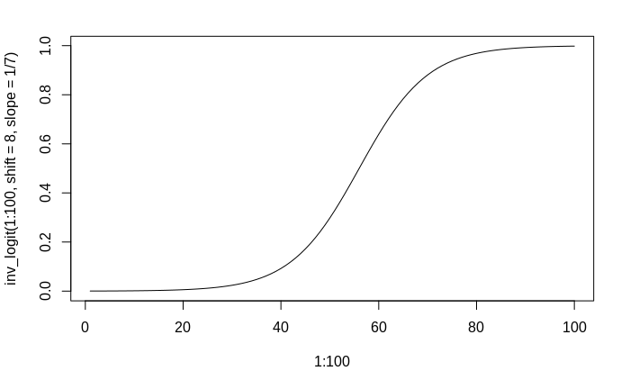

```r
inv_logit <- function(x, scale = 1, slope = 1, shift = 0) {
  x <- scale * exp(x*slope - shift)/(1+exp(x * slope - shift))
  for (i in 1:length(x)) {
    if (is.na(x[i])) {x[i] <- 1}
  }
  x
}

# let's see how the function works:
plot(x=1:100, y=inv_logit(1:100, shift = 8, slope = 1/7), type='l')
```

This function fits my expectations pretty well. By the age of 65 there should be enough accumulated lifetime risk to generate lots of cases. Next I want to see the consequences of different ages on my simulated patient population:

```r
ages <- c(rep(20, nvalid),
          rep(30, nvalid),
          rep(40, nvalid),
          rep(50, nvalid),
          rep(60, nvalid),
          rep(70, nvalid),
          rep(80, nvalid))

# people with BRCA1 mutations can get sick by age 30, so I'll set the onset age to 15 to allow 10 years for some risk to accumulate
ovcprobs.brca.age <- rep(ovcprobs.brca[valid.patients],7) * inv_logit(ages, shift = 8, slope = 1/7)

agerisk <- data.frame(age = as.factor(ages),
                      risk = ovcprobs.brca.age,
                      brca = as.factor(rep(brca.carrier[valid.patients], 7)))

gc()
```

```
           used (Mb) gc trigger  (Mb) max used  (Mb)
Ncells  1387802 74.2    3931197 210.0  3931197 210.0
Vcells 12197126 93.1   24423574 186.4 24423574 186.4
```

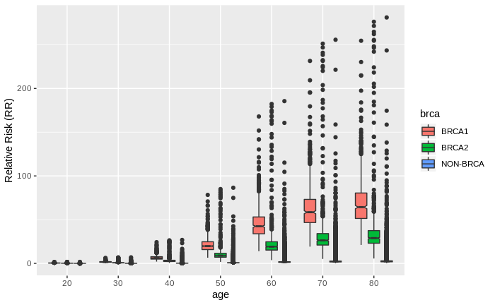

```r
ggplot(agerisk, aes(x = age, y = risk)) + geom_boxplot(aes(fill = brca), notch = TRUE) + labs(y="Relative Risk (RR)")
```

### Explanation

None currently

### Case vs control study

```r
# generate cases 'n ctrls from polygenic risk data
#########################
set.seed(29)
ages <- sample(40:80, size=num_pts, replace = TRUE)
probs <- ovcprobs.brca * inv_logit(ages, shift = 8, slope = 1/7)
probs <- probs[valid.patients]

ovcsick.brca <- matrix(nrow = nvalid, ncol = 100)

for (i in 1:nvalid) {
  ovcsick.brca[i,] <- sample(c(0,1), size=10, prob = c(1-popscale.factor*probs[i], popscale.factor*probs[i]), replace = TRUE)
}

pick.one <- sample(10, 1)

cases <- which(ovcsick.brca[,pick.one]==TRUE)
length(cases)
```

```
[1] 718
```

```r
length(cases)/nvalid
```

```
[1] 0.007181795
```

```r
probs.scale <- probs * popscale.factor

ctrls <- sample(which(ovcsick.brca[,pick.one]==FALSE), size = length(cases), replace = FALSE)
ptrisk <- melt(data.frame(ctrls=probs.scale[ctrls], cases=probs.scale[cases]))
names(ptrisk) <- c("trtgroup", "risk")
#########################

# average risk of BRCA1+ carriers (regardless of status)
mean(probs.scale[(brca.carrier=="BRCA1")[valid.patients]==TRUE])
```

```
[1] 0.1501058
```

```r
# average risk of BRCA2+ carriers
mean(probs.scale[(brca.carrier=="BRCA2")[valid.patients]==TRUE])
```

```
[1] 0.0762524
```

```r
# average risk of non-BRCA
mean(probs.scale[(brca.carrier=="NON-BRCA")[valid.patients]==TRUE])
```

```
[1] 0.005899514
```

```r
# of cases that are BRCA carriers (see double negative?)
sum(cases %in% which((brca.carrier=="NON-BRCA")[valid.patients]==FALSE))
```

```
[1] 169
```

```r
# fraction of cases that are BRCA1+ etc etc
sum(cases %in% which((brca.carrier=="BRCA1")[valid.patients]==TRUE))/length(cases)
```

```
[1] 0.1448468
```

```r
sum(cases %in% which((brca.carrier=="BRCA2")[valid.patients]==TRUE))/length(cases)
```

```
[1] 0.09052925
```

```r
sum(cases %in% which((brca.carrier=="NON-BRCA")[valid.patients]==TRUE))/length(cases)
```

```
[1] 0.764624
```

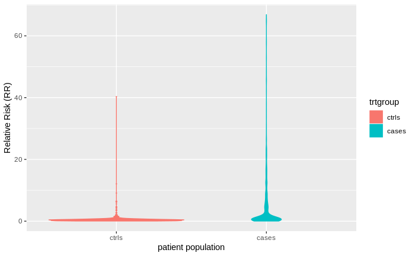

```r
# violin plot compare distributin relative risk of cases controls
ggplot(data=ptrisk, aes(x=trtgroup, y=risk/baserate, colour=trtgroup, fill=trtgroup)) + geom_violin() + labs(x = "patient population", y = "Relative Risk (RR)")
```

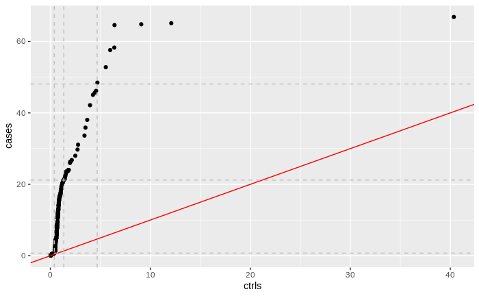

```r
ggplot(data=data.frame(cases=probs.scale[cases][order(probs.scale[cases])]/prevalence,
                       ctrls=probs.scale[ctrls][order(probs.scale[ctrls])]/prevalence), aes(x=ctrls, y=cases)) +
  geom_point() + #xlim(0, 20) + ylim(0, 200) +
  geom_abline(intercept = 0, slope = 1, colour="red") +
  geom_hline(yintercept=quantile(probs.scale[cases]/prevalence, probs=c(.5,.95,.99)), colour="grey", lty=2) +
  geom_vline(xintercept=quantile(probs.scale[ctrls]/prevalence, probs=c(.5,.95,.99)), colour="grey", lty=2)
```

```r
caseOR <- probs.scale[cases][order(probs.scale[cases])]/prevalence
ctrlOR <- probs.scale[ctrls][order(probs.scale[ctrls])]/prevalence
# % of cases OR > 5
length(which(caseOR>5))
```

```
[1] 170
```

```r
length(which(caseOR>5))/length(caseOR)
```

```
[1] 0.2367688
```

```r
# slope
mean(caseOR/ctrlOR)
```

```
[1] 5.509079
```

```r
# prevalence
length(cases)/nvalid
```

```
[1] 0.007181795
```

```r
# fraction of brca1+ patients that are cases
sum(cases %in% which(brca.carrier[valid.patients]=="BRCA1"))/sum(brca.carrier[valid.patients]=="BRCA1")
```

```
[1] 0.1656051
```

```r
# fraction of cases that are brca1+
sum(cases %in% which(brca.carrier[valid.patients]=="BRCA1"))/length(cases)
```

```
[1] 0.1448468
```

```r
# fraction of cases that are non-BRCA
sum(cases %in% which(brca.carrier[valid.patients]=="NON-BRCA"))/length(cases)
```

```
[1] 0.764624
```

```r
# fraction of BRCA2 patients that are cases
sum(cases %in% which(brca.carrier[valid.patients]=="BRCA2"))/sum(brca.carrier[valid.patients]=="BRCA2")
```

```
[1] 0.08034611
```

## All known mutations in ovarian cancer

This section contains what is basically a duplication of the previous sections, but with a newly obtained dataset of ALL known ovarian SNPs and mutations.

```r
################### BRCA Muts
prevalence <- 0.013

##                  1              2             3             4              5            6             7              8
ovc_snps <- c("rs56318008",  "rs58722170", "rs17041869", "rs2072590",   "rs2165109", "rs711830",   "rs752590",    "rs112071820", # A
              "rs7651446",   "rs9870207",  "rs13113999", "rs17329882",  "rs4691139", "rs10069690", "rs555025179", "rs6456822",   # B
              "rs7705526",   "rs10088218", "rs11782652", "rs150293538", "rs9886651", "rs1413299",  "rs200182588", "rs320203",    # C
              "rs3814113",   "rs635634",   "rs1192691",  "rs1243180",   "rs7902587", "rs7937840",  "rs7953249",   "rs8037137",   # D
              "rs199661266", "rs11651755", "rs183211",   "rs757210",    "rs9303542", "rs8098244",  "rs1469713",   "rs4808075",   # E
              "rs688187",    "rs6005807",  "brca1",      "brca2",       "brip1",     "palb2",      "rad51c",      "rad51d",      # F
              "bard1",       "chek2",      "atm",        "nbn",         "tp53",      "rad50",      "fam174a",     "mre11a")      # G

##              1     2     3     4     5     6     7     8
ovc_or   <- c(1.11, 1.08, 1.06, 1.34, 1.09, 1.14,  1.3, 1.29, # A
              1.59, 1.19,  1.2, 1.23, 1.09, 1.14, 1.51, 1.18, # B
              1.07, 1.24, 2.19, 1.23, 1.08, 1.21, 1.53, 1.04, # C
              1.29, 1.11, 1.11,  1.1, 1.29, 1.05, 1.08, 1.07, # D
              1.09,  1.2, 1.11, 1.11, 1.14, 1.19, 1.04, 1.18, # E
              1.33, 1.17,   29, 12.7,  6.4,  4.4,  3.4, 10.9, # F
              4.2,   0.4,  2.4,  2.3,  2.9,  0.7,  1.9,  0.8) # G

##                1         2         3         4         5         6         7         8
ovc_maf  <- c(0.796725, 0.151757, 0.874002, 0.817492, 0.740016, 0.8185,   0.763778, 0.73722,  # A
              0.939896, 0.487021, 0.226438, 0.848243, 0.363219, 0.652356, 0.54173,  0.4623,   # B
              0.321486, 0.086661, 0.945487, 0.992612, 0.725839, 0.580072, 0.4868,   0.176717, # C
              0.44389,  0.139776, 0.758387, 0.159545, 0.91893,  0.857628, 0.56889,  0.282348, # D
              0.8676,   0.467252, 0.287784, 0.3622,   0.684904, 0.173922, 0.478035, 0.154752, # F
              0.358427, 0.886981, 0.0031,   0.0041,   0.0017,   0.0011,   0.0011,   0.0004,   # F
              0.0005,   0.0082,   0.0022,   0.0014,   0.0011,   0.0024,   0.0008,   0.0007)   # G


ovcpts <- pt_genotypes(num_pts, ovc_snps, ovc_maf, effect_size = ovc_or)
ovcodds <- exp(colSums(log(ovcpts$OR ^ ovcpts[,1:num_pts])))
gc()
```

```
           used  (Mb) gc trigger  (Mb) max used  (Mb)
Ncells  1403286  75.0    3931197 210.0  3931197 210.0
Vcells 24949620 190.4   62694948 478.4 62666624 478.2
```

```r
brca.carrier <- rep("NON-BRCA", num_pts)
brca.carrier[which(ovcpts[14,1:1e5]>0)] <- "BRCA2"
brca.carrier[which(ovcpts[13,1:1e5]>0)] <- "BRCA1" # assign brca1 last in case of overwriting double mutation status

ovcprobs.brca <- ovcodds
popscale.factor <- 2 * prevalence / mean(ovcprobs.brca)
valid.patients <- which(ovcprobs.brca*popscale.factor < 1)

nvalid <- length(valid.patients)

ages <- c(rep(20, nvalid),
          rep(30, nvalid),
          rep(40, nvalid),
          rep(50, nvalid),
          rep(60, nvalid),
          rep(70, nvalid),
          rep(80, nvalid))

agerisk <- data.frame(age      = as.factor(ages),
                      risk     = rep(ovcprobs.brca[valid.patients], 7),
                      brca     = as.factor(rep(brca.carrier[valid.patients], 7)),
                      risk.age = rep(ovcprobs.brca[valid.patients], 7) * inv_logit(ages, shift = 8, slope = 1/7) * popscale.factor)

gc()
```

```
           used  (Mb) gc trigger  (Mb) max used  (Mb)
Ncells  1403281  75.0    3931197 210.0  3931197 210.0
Vcells 26097141 199.2   62694948 478.4 62666624 478.2
```

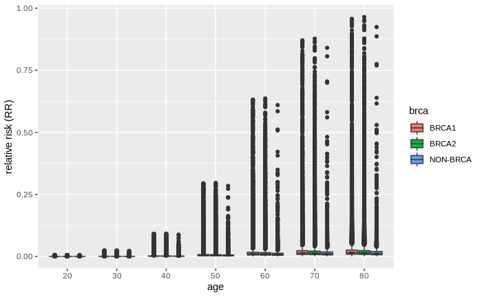

```r
ggplot(agerisk, aes(x = age, y = risk.age)) + geom_boxplot(aes(fill = brca), notch = TRUE) + labs(y="relative risk (RR)") #+ scale_y_log10()
```

```r
# generate cases 'n ctrls from polygenic risk data
#########################
set.seed(29)
ages <- sample(40:80, size=num_pts, replace = TRUE)
probs <- ovcprobs.brca * inv_logit(ages, shift = 8, slope = 1/7)
probs <- probs[valid.patients]

ovcsick.brca <- matrix(nrow = nvalid, ncol = 100)

for (i in 1:nvalid) {
  ovcsick.brca[i,] <- sample(c(0,1), size=10, prob = c(1-popscale.factor*probs[i], popscale.factor*probs[i]), replace = TRUE)
}

pick.one <- sample(10, 1)

cases <- which(ovcsick.brca[,pick.one]==TRUE)
length(cases)
```

```
[1] 1395
```

```r
length(cases)/nvalid
```

```
[1] 0.01396354
```

```r
probs.scale <- probs * popscale.factor

ctrls <- sample(which(ovcsick.brca[,pick.one]==FALSE), size = length(cases), replace = FALSE)
ptrisk <- melt(data.frame(ctrls=probs.scale[ctrls], cases=probs.scale[cases]))
names(ptrisk) <- c("trtgroup", "risk")
#########################


length(probs.scale)
```

```
[1] 99903
```

```r
mean(probs.scale[(brca.carrier=="BRCA1")[valid.patients]==TRUE])
```

```
[1] 0.01485184
```

```r
mean(probs.scale[(brca.carrier=="BRCA2")[valid.patients]==TRUE])
```

```
[1] 0.01371639
```

```r
mean(probs.scale[(brca.carrier=="NON-BRCA")[valid.patients]==TRUE])
```

```
[1] 0.01204372
```

```r
# of cases that are BRCA carriers (see double negative?)
sum(cases %in% which((brca.carrier=="NON-BRCA")[valid.patients]==FALSE))
```

```
[1] 1341
```

```r
# fraction of cases that are BRCA1+
sum(cases %in% which((brca.carrier=="BRCA1")[valid.patients]==TRUE))/length(cases)
```

```
[1] 0.6250896
```

```r
sum(cases %in% which((brca.carrier=="BRCA2")[valid.patients]==TRUE))/length(cases)
```

```
[1] 0.3362007
```

```r
sum(cases %in% which((brca.carrier=="NON-BRCA")[valid.patients]==TRUE))/length(cases)
```

```
[1] 0.03870968
```

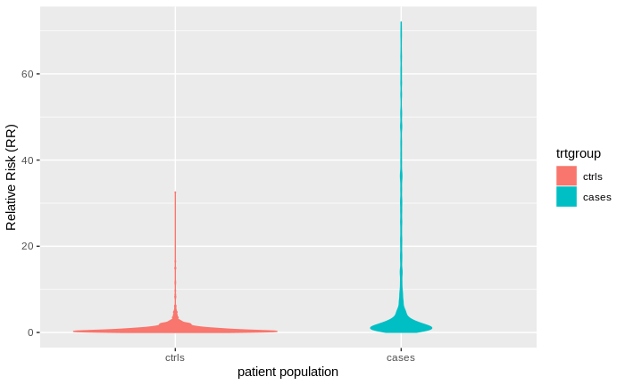

```r
# violin plot compare distributin relative risk of cases controls
ggplot(data=ptrisk, aes(x=trtgroup, y=risk/baserate, colour=trtgroup, fill=trtgroup)) + geom_violin() + labs(x = "patient population", y = "Relative Risk (RR)")
```

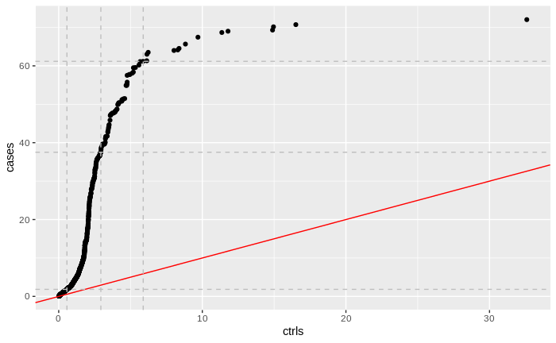

```r
ggplot(data=data.frame(cases=probs.scale[cases][order(probs.scale[cases])]/prevalence,
                       ctrls=probs.scale[ctrls][order(probs.scale[ctrls])]/prevalence), aes(x=ctrls, y=cases)) +
  geom_point() + #xlim(0, 20) + ylim(0, 200) +
  geom_abline(intercept = 0, slope = 1, colour="red") +
  geom_hline(yintercept=quantile(probs.scale[cases]/prevalence, probs=c(.5,.95,.99)), colour="grey", lty=2) +
  geom_vline(xintercept=quantile(probs.scale[ctrls]/prevalence, probs=c(.5,.95,.99)), colour="grey", lty=2)
```

```r
caseOR <- probs.scale[cases][order(probs.scale[cases])]/prevalence
ctrlOR <- probs.scale[ctrls][order(probs.scale[ctrls])]/prevalence
# % of cases OR > 5
length(which(caseOR>5))
```

```
[1] 333
```

```r
length(which(caseOR>5))/length(caseOR)
```

```
[1] 0.2387097
```

```r
# slope
mean(caseOR/ctrlOR)
```

```
[1] 4.708443
```

```r
# prevalence
length(cases)/nvalid
```

```
[1] 0.01396354
```

```r
# fraction of brca1 patients that are cases
sum(cases %in% which(brca.carrier[valid.patients]=="BRCA1"))/sum(brca.carrier[valid.patients]=="BRCA1")
```

```
[1] 0.01468261
```

```r
# fraction of BRCA2 patients that are cases
sum(cases %in% which(brca.carrier[valid.patients]=="BRCA2"))/sum(brca.carrier[valid.patients]=="BRCA2")
```

```
[1] 0.01317971
```

```r
# fraction of cases that are brca1+
sum(cases %in% which(brca.carrier[valid.patients]=="BRCA1"))/length(cases)
```

```
[1] 0.6250896
```

```r
# fraction of cases that are non-BRCA
sum(cases %in% which(brca.carrier[valid.patients]=="NON-BRCA"))/length(cases)
```

```
[1] 0.03870968
```

# Acknowledgements

Special thanks to Simon G. Coetzee and Michelle Jones for discussions and feedback and SGC on making the R code more efficient.

[^1]: This table was put together before I introduced age and population mean adjustments, so the odds ratios are wrong, but the conclusions, in particular the slopes, are largely the same.
[^2]: See Antoniou A, Pharoah PD, Narod S, et al. Average risks of breast and ovarian cancer associated with BRCA1 or BRCA2 mutations detected in case series unselected for family history: A combined analysis of 22 studies. American Journal of Human Genetics 2003; 72(5):1117–1130.
[^3]: Norquist et al “Inherited Mutations in Women With Ovarian Carcinoma”. [(2016) JAMA Oncology 2(4):482–490](http://jamanetwork.com/journals/jamaoncology/fullarticle/2479125).